```python
import numpy as np
import skimage as sk
import skimage.io as skio
import skimage.transform
import skimage.color as sc
import time

from scipy.signal import convolve2d
from scipy.signal import convolve
from scipy.ndimage.interpolation import rotate
import cv2

import seaborn as sns
import matplotlib.pyplot as plt

import warnings
warnings.filterwarnings('ignore')
```

# Project 2: Fun with Filters and Frequencies!

# Part 1: Fun with Filters

## Part 1.1: Finite Difference Operator

In the first section, we use the finite difference operators to generate derivative images, compute the gradient magnitude image, and apply a binary threshold mask to find the edges of the image. We find the gradient magnitude image by finding the magnitude of the sum of our squared derivative matrices.

$ M = \sqrt{(dx^2 + dy^2)}$

```python
cman = skio.imread('cameraman.png')
cgray = sc.rgb2gray(cman)
D_x = np.array([[1, -1],
                 [0, 0]])
D_y = np.array([[1, 0],
                [-1, 0]])
```

**Image of Camera Man**

[figure not shown]

```python
skio.imshow(cgray);
```

```python
cd_x = convolve2d(cgray, D_x)
cd_y = convolve2d(cgray, D_y)
```

```python
# Gradient Magnitude Image
c_gradient = np.sqrt(cd_x**2 + cd_y**2)
```

```python
# plt.title('dx image')
# plt.imshow(cd_x, cmap='gray')
# plt.axis('off')
# plt.imsave('cd_x.jpg', cd_x, cmap='gray')

# plt.title('dy image')
# plt.imshow(cd_y, cmap='gray')
# plt.axis('off');
# plt.imsave('cd_y.jpg', c_gradient, cmap='gray')

# plt.title('gradient magnitude image')
# plt.imshow(c_gradient, cmap='gray')
# plt.axis('off');
# plt.imsave('cd_gradient.jpg', c_gradient, cmap='gray')
```

With a threshold of 0.15, the edges of our image are extremely noisy, especially with the water pixels around the bottom:

```python
# Threshold of 0.05 to suppress noise while still detecting borders
skio.imshow((c_gradient>0.15));
plt.imsave('thresh.jpg', (c_gradient>0.15), cmap='gray')
```

[figure not shown]

## 1.2 Derivative of Gaussian (DoG) Filter

Our results from 1.1 hint that a simple derivative filter is not enough to detect the edges of our image. In this section, we smooth our image with gaussian filter to remove noise before convoluting with the finite difference vectors.

```python
#
g_1d = cv2.getGaussianKernel(ksize=6, sigma=2)
g_2d = g_1d @ g_1d.T
```

```python
# Apply Gaussian Smoothing to image and convolve smoothed image with finite difference vectors
cam_smoothed = convolve2d(cgray, g_2d)
cam_smooth_x = convolve2d(cam_smoothed, D_x)
cam_smooth_y = convolve2d(cam_smoothed, D_y)
c_smooth_gradient = np.sqrt(cam_smooth_x**2 + cam_smooth_y**2)
```

## With Gaussian Smoothing

```python
# plt.title('smooth dx image')
# plt.imshow(cam_smooth_x, cmap='gray')
# plt.axis('off')
# plt.imsave('scd_x.jpg', cd_x, cmap='gray')

# plt.title('smooth dy image')
# plt.imshow(cam_smooth_y, cmap='gray')
# plt.axis('off');
# plt.imsave('scd_y.jpg', c_gradient, cmap='gray')

# plt.title('smooth gradient magnitude image')
# plt.imshow(c_smooth_gradient, cmap='gray')
# plt.axis('off');
# plt.imsave('scd_gradient.jpg', c_gradient, cmap='gray')
```

```python
# skio.imshow((c_smooth_gradient>0.05));
# plt.imsave('c_smooth.jpg', (c_smooth_gradient>0.05), cmap='gray')
```

[figure not shown]

After applying gaussian smoothing to the image with a threshold of 0.05, we see that the edges are much bolder and less noisy (especially around the bottom with the water pixels). We are also able to maintain difficult edges like the tall building in the back by setting a low threshold value without the image being too blurry.

## Derivative of Gaussian Filter

We can achieve the same solution by convolving the gaussian filter with the finite difference vectors before convolving with our original image to save computation time. Below, we verify that we get the same result.

```python
gauss_dx = convolve2d(g_2d, D_x)
gauss_dy = convolve2d(g_2d, D_y)
man_gauss_dx = convolve2d(cgray, gauss_dx)
man_gauss_dy = convolve2d(cgray, gauss_dy)
```

[figure not shown]

```python
plt.imshow(gauss_dx, cmap='gray')
plt.axis('off')
plt.imsave('gauss_x.jpg', gauss_dx, cmap='gray')

plt.imshow(gauss_dy, cmap='gray')
plt.axis('off');
plt.imsave('gauss_y.jpg', gauss_dy, cmap='gray')

plt.imshow(man_gauss_dx, cmap='gray')
plt.axis('off');
plt.imsave('man_gauss_dx.jpg', man_gauss_dx, cmap='gray')

plt.imshow(man_gauss_dy, cmap='gray')
plt.axis('off');
plt.imsave('man_gauss_dy.jpg', man_gauss_dx, cmap='gray')
```

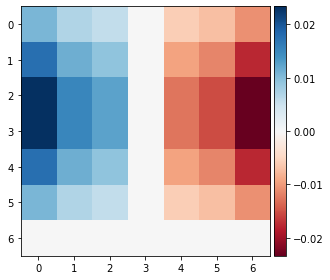

```python
skio.imshow(gauss_dx)
```

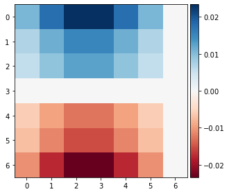

```python
skio.imshow(gauss_dy)
```

## Derivative of Gaussian (dx) and Derivative of Gaussian (dy)

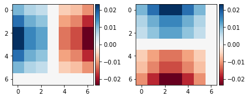

```python
plt.subplot(1, 2, 1)
skio.imshow(gauss_dx)

plt.subplot(1, 2, 2)
skio.imshow(gauss_dy);
```

## Convolution with Derivative of dx and dy Gaussians

```python
# c_gauss_gradient = np.sqrt(man_gauss_dx**2 + man_gauss_dy**2)
# skio.imshow((c_gauss_gradient>0.05));
# plt.imsave('c_gauss_grad.jpg', (c_gauss_gradient>0.05), cmap='gray')
```

[figure not shown]

We see that blurring the image first and then convolving with the finite difference vectors produces the exact same magnitude image as convolving with the partial derivatives of the gaussian filter.

## 1.3 Image Straightening

In this section, we attempt to automatically straighten images by rotating it to maximize the amount of "edges". We can compute the gradient angle of each pixel of an image by finding the tangent angle between the derivative of the image in the y direction and the derivative of the angle in the x direction.

```python
rotation_angles = np.arange(-179, 180, 2)
num_edges = {}

img_path = 'stairs.jpg'
img = skio.imread(img_path, as_gray=True)

for angle in rotation_angles:
    # Rotate and crop image
    rotated = rotate(img, angle, mode='constant', reshape=True)
    crop_x = int(rotated.shape[0] * 0.3)
    crop_y = int(rotated.shape[1] * 0.3)
    rotated = rotated[crop_x:rotated.shape[0]-crop_x, crop_y:rotated.shape[1]-crop_y]

    # Convolve image with derivative of gaussian filter
    rotated_dx = convolve2d(rotated, gauss_dx)
    rotated_dy = convolve2d(rotated, gauss_dy)

    # Compute gradient angles/magnitudes
    grad_angles = np.arctan2(rotated_dy, rotated_dx)
    angle_mags = np.sqrt(rotated_dx**2 + rotated_dy**2)

    # Count proportion of edge pixels relative to total pixels
    total_edges = 0
    total_edges += ((grad_angles >= -0.001) & (grad_angles < 0.001))[angle_mags > 0.05].sum()
    total_edges += ((grad_angles >= np.pi/2-0.001) & (grad_angles < np.pi/2+0.001))[angle_mags > 0.05].sum()
    total_edges += ((grad_angles >= np.pi-0.001) & (grad_angles < np.pi+0.001))[angle_mags > 0.05].sum()
    total_edges += ((grad_angles >= 3*np.pi/2-0.001) & (grad_angles < 3*np.pi/2+0.001))[angle_mags > 0.05].sum()
    num_edges[angle] = total_edges / (grad_angles.shape[0] * grad_angles.shape[1])

#     print(angle, ': ', num_edges[angle])
#     sns.distplot((180/np.pi) * grad_angles[angle_mags > 0.05], kde=False)
#     plt.title(f'Distribution of Horizontal and Vertical Edges for Clockwise Rotation of {abs(angle)} degrees')
#     plt.show()
```

```python
best_angle = max(num_edges, key=num_edges.get)
img = skio.imread(img_path, as_gray=True)

for angle in [0, best_angle]:
# Histogram of gradient angles (best angle)
    rotated = rotate(img, angle, mode='constant', reshape=True)
    crop_x = int(rotated.shape[0] * 0.3)
    crop_y = int(rotated.shape[1] * 0.3)
    rotated = rotated[crop_x:rotated.shape[0]-crop_x, crop_y:rotated.shape[1]-crop_y]

    # Convolve image with derivative of gaussian filter
    rotated_dx = convolve2d(rotated, gauss_dx)
    rotated_dy = convolve2d(rotated, gauss_dy)

    # Compute gradient angles/magnitudes
    grad_angles = np.arctan2(rotated_dy, rotated_dx)
    angle_mags = np.sqrt(rotated_dx**2 + rotated_dy**2)

    plt.hist((180/np.pi) * grad_angles[angle_mags > 0.05].flatten(), bins=np.arange(-180, 181, 5))
    plt.title(f'Distribution of gradient angles for image rotated {angle} counter clockwise')
    plt.savefig(f'{img_path}_hist_{angle}.png')
    plt.xlabel('angle')
    plt.ylabel('count')
    plt.title('Distribution of gradient angles')
    plt.clf()
```

```python
img_path = 'stairs.jpg'
img = skio.imread(img_path, as_gray=False)
rotated_img = rotate(img, best_angle, reshape=True, mode='constant')
crop_x = int(rotated_img.shape[0] * 0.2)
crop_y = int(rotated_img.shape[1] * 0.2)
rotated_img = rotated_img[crop_x:rotated_img.shape[0]-crop_x, crop_y:rotated_img.shape[1]-crop_y]
skio.imshow(rotated_img)
skio.imsave(f'rotated_{img_path}', rotated_img)
```

# Part 2: Fun with Frequencies!

## Part 2.1: Image "Sharpening"

In the next section, we apply an "unsharp" mask to an image to artificially make it appear sharper. We effectively achieve this by detecting the high frequency pixels in our image and adding only the high frequency pixels to our image.

```python
taj = skio.imread('taj.jpg')
```

```python
taj_r = taj[:, :, 0]
taj_g = taj[:, :, 1]
taj_b = taj[:, :, 2]
```

```python
taj_smooth_r = convolve2d(taj_r, g_2d, mode='same')
taj_smooth_g = convolve2d(taj_g, g_2d, mode='same')
taj_smooth_b = convolve2d(taj_b, g_2d, mode='same')
```

```python
alpha = 1
taj_sharp_r = taj_r + alpha * (taj_r - taj_smooth_r)
taj_sharp_g = taj_g + alpha * (taj_g - taj_smooth_g)
taj_sharp_b = taj_b + alpha * (taj_b - taj_smooth_b)
```

```python
taj_sharp = np.dstack((taj_sharp_r, taj_sharp_g, taj_sharp_b))
taj_sharp = np.clip(taj_sharp, 0, 255)
skio.imsave('taj_sharp.jpg', taj_sharp)
```

```python
def sharpen(img_path, alpha):
    img = skio.imread(img_path)
    skio.imshow(img)
    img_r = img[:, :, 0]
    img_g = img[:, :, 1]
    img_b = img[:, :, 2]
    img_smooth_r = convolve2d(img_r, g_2d, mode='same')
    img_smooth_g = convolve2d(img_g, g_2d, mode='same')
    img_smooth_b = convolve2d(img_b, g_2d, mode='same')
    img_sharp_r = img_r + alpha * (img_r - img_smooth_r)
    img_sharp_g = img_g + alpha * (img_g - img_smooth_g)
    img_sharp_b = img_b + alpha * (img_b - img_smooth_b)
    img_sharp = np.dstack((img_sharp_r, img_sharp_g, img_sharp_b))
    img_sharp = np.clip(img_sharp, 0, 255)
    skio.imsave(f'{img_path}_sharp.jpg', img_sharp)
    skio.imshow(img_sharp/255)
```

We can also make the sharpening process more efficient by rearranging the operations of our convolution:

$f + \alpha(f - f\star g) = f\star ((1+\alpha)e - \alpha g)$

```python
unit_impulse = np.zeros((g_2d.shape[0], g_2d.shape[1]))
unit_impulse[2:4, 2:4] = 1
```

```python
def sharpen_efficient(img_path, alpha):
    img = skio.imread(img_path)
    skio.imshow(img)
    img_r = img[:, :, 0]
    img_g = img[:, :, 1]
    img_b = img[:, :, 2]
    ag = g_2d * alpha
    conv_exp = (1+alpha)*unit_impulse - ag
    img_sharp_r = convolve2d(img_r, conv_exp, mode='same')
    img_sharp_g = convolve2d(img_g, conv_exp, mode='same')
    img_sharp_b = convolve2d(img_b, conv_exp, mode='same')
    img_sharp = np.dstack((img_sharp_r, img_sharp_g, img_sharp_b))
    img_sharp = np.clip(img_sharp, 0, 255)
    skio.imsave(f'{img_path}_sharp', img_sharp)
    skio.imshow(img_sharp/255)
```

```python
# sharpen('cars.jpg', 10)
```

```python
# sharpen('forest.jpg', 5)
```

### Next, we attempt to re-sharpen an already sharp image by blurring it first...

```python
# img = skio.imread('road.jpg')
# skio.imshow(img)
```

```python
# img_r, img_g, img_b = img[:, :, 0], img[:, :, 1], img[:, :, 2]
# img_blurry = np.dstack((convolve2d(img_r, g_2d),
#                          convolve2d(img_g, g_2d),
#                          convolve2d(img_b, g_2d)))
# skio.imshow(img/255)
# skio.imsave('road_blurry.jpg', img_blurry)
```

```python
# sharpen('road_blurry.jpg', 5)
```

# Part 2.2 Hybrid Images

We can create hybrid images that appear differently depending on how close or far away you view the image by modifying each image to either only have low or high frequencies and combining the two images. The low frequency image should appear at further distances, while the high frequency image should appear at closer distances.

```python
import align_image_code
from align_image_code import align_images
import matplotlib
%matplotlib inline

# First load images

matplotlib.use('TkAgg')

im1 = plt.imread('./DerekPicture.jpg')/255.
im2 = plt.imread('./nutmeg.jpg')/255

# Next align images (this code is provided, but may be improved)
im2_aligned, im1_aligned = align_images(im2, im1)
```

```python
## Derek should be low pass (gaussian filter), Nutmeg should be highpass (impulse - gaussian)

matplotlib.use('module://ipykernel.pylab.backend_inline')
plt.subplot(1, 2, 1)
plt.imshow(im2_aligned);

plt.subplot(1, 2, 2)
plt.imshow(im1_aligned);
```

```python
sigma1 = 0.8
sigma2 = 3
im2_aligned = sc.rgb2gray(im2_aligned)
im1_aligned = sc.rgb2gray(im1_aligned)
```

```python
im1_blurred = convolve2d(im1_aligned, g_2d, mode='same')
im1_blurred = (im1_blurred < sigma1) * im1_blurred
skio.imshow(im1_blurred, cmap='gray')
```

```python
alpha = 1
im2_sharpened = convolve2d(im2_aligned, (1+alpha)*unit_impulse - alpha*g_2d, mode='same')
im2_sharpened = (im2_sharpened > sigma2) * im2_sharpened
skio.imshow(im2_sharpened)
```

```python
combined_image = (im1_blurred + im2_sharpened*0.1)
plt.imshow(combined_image, cmap='gray')
skio.imsave('combined.jpg', combined_image);
```

```python
def merge_images(img1, img2, sigma1, sigma2):

    #img1 = low frequency
    #img2 = high frequency
    # First load images


    %matplotlib inline
    matplotlib.use('TkAgg')

    im1 = plt.imread(img1)/255.
    im2 = plt.imread(img2)/255
    im2_aligned, im1_aligned = align_images(im2, im1)

    matplotlib.use('module://ipykernel.pylab.backend_inline')
#     plt.subplot(1, 2, 1)
#     plt.imshow(im2_aligned);

#     plt.subplot(1, 2, 2)
#     plt.imshow(im1_aligned);

    # convert to grayscale
    im2_aligned = sc.rgb2gray(im2_aligned)
    im1_aligned = sc.rgb2gray(im1_aligned)

    # Apply gaussian blur filter to img 1
    im1_blurred = convolve2d(im1_aligned, g_2d, mode='same')
    im1_blurred = (im1_blurred < sigma1) * im1_blurred

    # Sharpen img 2 by convovling with laplacian of gaussian
    alpha = 1
    im2_sharpened = convolve2d(im2_aligned, (1+alpha)*unit_impulse - alpha*g_2d, mode='same')
    im2_sharpened = (im2_sharpened > sigma2) * im2_sharpened

    # Weighted sum of img1 and 0.1*img2
    combined_image = (im1_blurred + im2_sharpened*0.1)
    skio.imsave(f'{img1}_{img2}', combined_image);
```

```python
merge_images('cubone.jpg', 'puppy.jpg', 0.8, 4)
```